# Working with Markdown

Nicole R Gorman

2024-01-23

For markdown, use asterisks to *indicate italic text*.

```r
#first chunk of code in rmd file
print(pi)
```

```
## [1] 3.141593
```

```r
pi + 3
```

```
## [1] 6.141593
```

Double line return for a new chunk of text like this.

Nicole R. Gorman  
Department of Plant Biology  
University of Vermont

**# Practice with RMarkdown code**  
**## Different language to change formatting**

# Hash marks for headers

## More hashes for progressively

## smaller

### and smaller

#### headers!!

**bold face this way**

> Offset quote which embeds and looks really nice when you have extended material that you would like to see.

Back to plain text

- first list item
- second list item
  - spacing for indents

<sup>superscript</sup> but also a <sub>superscript</sub> like this

set up a link with text

| First Header | Second Header |
| --- | --- |
| Content Cell | Content Cell |
| Content Cell | Content Cell |

’’’ Fencing sets boundaries and everything inside the fencing *is shown as literal text* without rendering. ’’’

$$a + b =c$$

We can also use Latex in the line with a single dollar sign $a + b=c$ like this.

##subscripts in LaTex

$$H_0 = Z_{a + b}$$

$$S=cA^z_1+ z_(Z + x)$$

$$\alpha = \frac{\best}{\delta +
\gamma_x}$$
$$z =
\sum_{i=1}^X{K}$$

### What if we need a backslash??

$$\backslash \alpha \le b \
\backslash$$

### Sometimes we want to mix math with plain text?

$$P(Occurance Of Species A) = Z$$
$$P(\mbox{Occurance Of Species A}) =
Z$$

East to embed Latex in line $\pi + 3$ like so we can also use markdown fencing in line with a single backtick `pi + 3` like this. We can even execute r code inside markdown text 6.1415927

# Rendering in plain text

We can run and execute R code within the R Markdown file. We can add code insode the fencing.

```r
# use the eval statement to toggle

#{r eval=TRUE, echo=FALSE}
# Commented this bc notr working

# Use comments extensively in all of your coding!
Pred <-seq(1,10)   #make a vector of integers from 1 to 10
Res <-runif(10)    #generate 10 draws from a random uniform (0,1) distribution

# Print random numbers
print(Res)
```

```
##  [1] 0.84539566 0.86149472 0.98247226 0.05286691 0.08985565 0.72970195
##  [7] 0.42092781 0.81084159 0.22235193 0.68246549
```

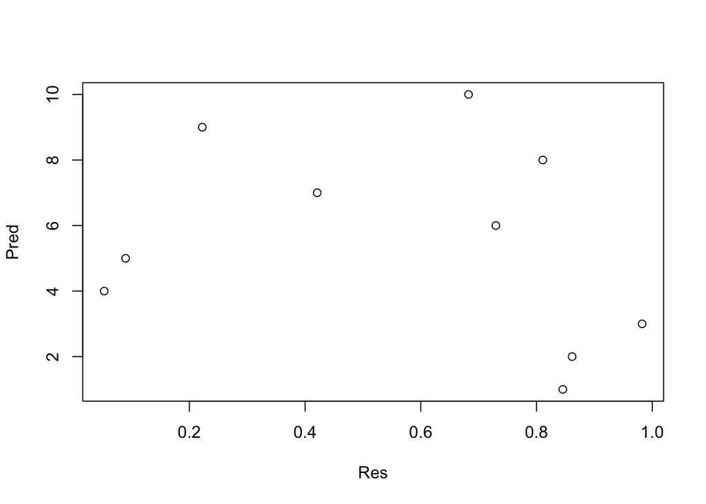

```r
plot(Res,Pred)
```